# DATA 607: Final Project

Chunsan Yip

5/10/2020

# Introduction

My company is spending a lot of money on Digital Marketing and I am the main person to purchase impressions and clicks from online media. While I am using an agency to purchase for us, I would like to find out the relationship between click and demography of users. I need to build a predictor model or build a basic recommender. It will help me to understand how to target audience for online advertisement purchase.

Initially, I was going to use the following as mentioned in my proposal: https://labs.criteo.com/2014/02/download-dataset/. The dataset doesn’t have column names and I don’t know what it means.

I download another dataset from Taobao/Alimama which is a subsidiary of Alibaba.

# Overall Process

OSEMN Process 1. Obtain Data 2. Scrub Data 3. Explore Data 4. Model Data 5. Interpret Results

# Data gathering

```r
#Create a function to extract and read CSV. Download to local drive method.

exCSV <- function(theUrl){
  fname <- str_extract(theUrl, "[^/]+(?=\\.tar.gz$)")
  untar(theUrl, files=fname, exdir="C:/Users/dansa/Documents/")
  read_csv(file=fname, na = c("", "NA"))
}


#Set the working directory from which the files will be read from
setwd("C:/Users/dansa/Documents/")

theUrl1 <- "C:/Users/dansa/Documents/user_profile.csv.tar.gz"
theUrl2 <- "C:/Users/dansa/Documents/ad_feature.csv.tar.gz"
theUrl3 <- "C:/Users/dansa/Documents/raw_sample.csv.tar.gz"

userProfile <- exCSV(theUrl1)
adFeature <- exCSV(theUrl2)
rawSample <- exCSV(theUrl3)
```

# Scrub and tidy up the data for analysis

```r
#Rename columns according to the definition of columns

userProfile1 <- userProfile %>%
  dplyr:: rename("user"=userid,
                 "cms_seg"= cms_segid,
                 "cms_group"=cms_group_id,
                 "gender"=final_gender_code,
                 "age_group"=age_level,
                 "purchase_level"=pvalue_level,
                 "college_graduate"=occupation,
                 "city_type"=new_user_class_level)%>%
  select(-starts_with("cms"))

adFeature1 <- adFeature %>%
  dplyr:: rename("ad"=adgroup_id,
                 "category"=cate_id,
                 "campaign"=campaign_id,
                 "ad_customer"=customer,
                 ) #The price for the product, a product represented by an ad, a product belongs to a cateogry and a brand

rawSample1 <- rawSample %>%
  dplyr:: rename("ad"=adgroup_id,
                 "ad_location"=pid,
                 "click"=clk
                ) %>%
  mutate("date" = as.Date(as_datetime(time_stamp))) %>%
  select(-nonclk, -time_stamp) #nonclk and clk are complement column. nonclk is removed.#The price for the product, a product represented by an ad, a product belongs to a cateogry and a brand
#  mutate(total_click = nonclk + clk)
```

# Exploring the dataset

```r
#Even though I tried to make use of all the data, my computer keeps giving me error message on file size. I decides to scale down the dataset by just pick up one tenth of the data.
set.seed(1001)
randRawSam <- rawSample1[sample(nrow(rawSample1), 2655000),]

#The adfeature and raw sample dataframe are joined together
rawad <- randRawSam %>%
  left_join(adFeature1, by="ad")

#The user profile and raw sample dataframe are joined together
rawuser <- randRawSam %>%
  left_join(userProfile1, by="user")%>%
  select(-user, -ad_location, -date)%>%
  na.omit()
```

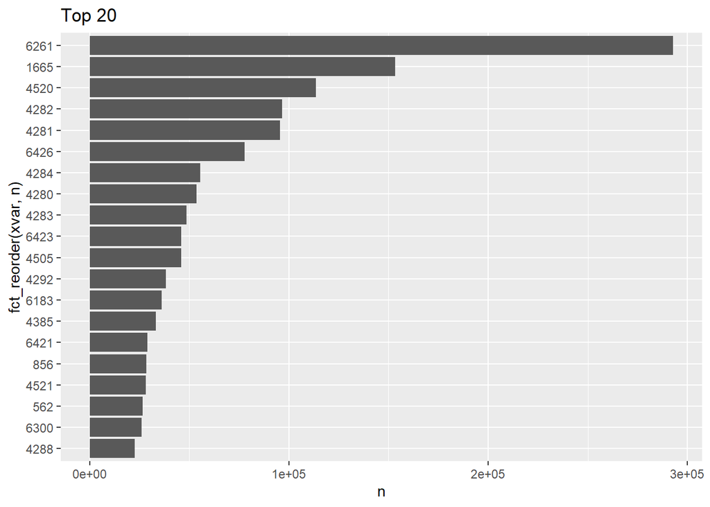

```r
#Create functions to change datasets and to plot top 20 set case by product category, brand, campaign and ad customer

sum20 <- function(xvar){
df<-rawad%>%
  mutate(xvar=sapply(xvar, as.factor))%>%
  group_by(xvar)%>%
  summarize(n=n())%>%
  arrange(desc(n))%>%
  top_n(20)
return(df)
}

plotsum20 <- function(dfsum20){
ggplot(dfsum20)+
  geom_col(mapping=aes(x=fct_reorder(xvar,n), y=n))+
  coord_flip()+
  ggtitle(paste("Top 20 "))
}

r <- vector(mode = "list", length = 4)

for(i in 1:4){
 r[[i]] <- sum20(rawad[,(i+5)])
}
plotsum20(r[[1]])
```

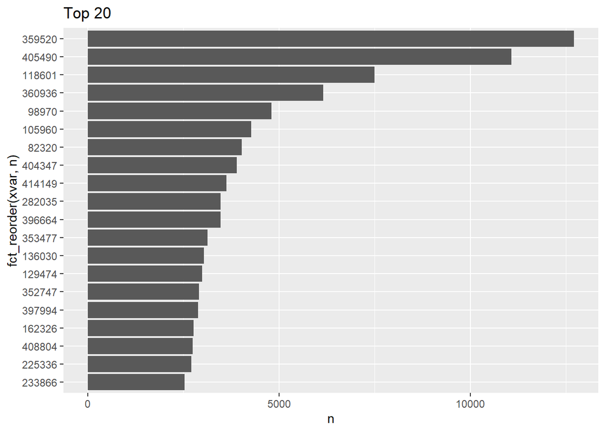

```r
plotsum20(r[[2]])
```

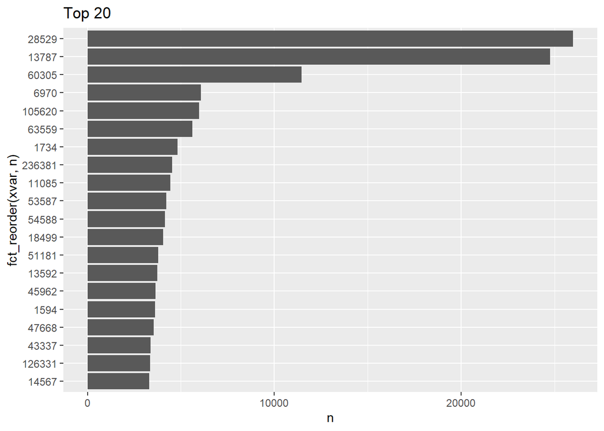

```r
plotsum20(r[[3]])
```

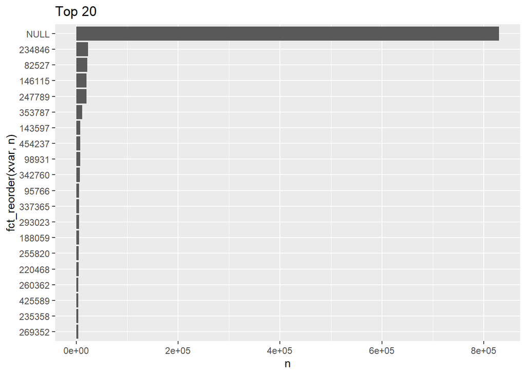

```r
plotsum20(r[[4]])
```

```r
#Calculate the click %
mean(rawad$click)
```

```
## [1] 0.05144595
```

The click rate is about 5% which is high against the industrial benchmark of 1% as we normal purchase.